# Lista2

2022-05-24

# Questão 3

# Banco de dados da Questão 3

```
##    radio censura
## 1      7       1
## 2     34       1
## 3     42       1
## 4     63       1
## 5     64       1
## 6     74       1
## 7     83       1
## 8     84       1
## 9     91       1
## 10   108       1
## 11   112       1
## 12   129       1
## 13   133       1
## 14   133       1
```

[output cut: 37 more lines]

## Letra A

*A função de sobrevivência por meio dos estimadores de Kaplan-Meier e de Nelson-Aalen. Apresente-as em tabelas e gráficos.*

Entendendo a documentação do pacote `Survival`

```
## # A tibble: 10 x 4
##    Estimate_KM  time Estimate_NH Estimate_NH2
##          <dbl> <dbl>       <dbl>        <dbl>
##  1       0.980     7       0.981        0.981
##  2       0.961    34       0.961        0.961
##  3       0.941    42       0.942        0.942
##  4       0.922    63       0.922        0.922
##  5       0.902    64       0.903        0.903
##  6       0.882    74       0.883        0.883
##  7       0.863    83       0.864        0.864
##  8       0.843    84       0.845        0.845
##  9       0.824    91       0.825        0.825
## 10       0.804   108       0.806        0.806
```

Assim podemos ver que os dois jeitos aparentemente são iguais.

```
##  [1]  TRUE  TRUE  TRUE  TRUE  TRUE  TRUE  TRUE  TRUE  TRUE  TRUE  TRUE  TRUE
## [13]  TRUE  TRUE FALSE FALSE  TRUE  TRUE  TRUE  TRUE  TRUE  TRUE  TRUE  TRUE
## [25]  TRUE FALSE FALSE  TRUE  TRUE FALSE FALSE  TRUE  TRUE  TRUE  TRUE FALSE
## [37] FALSE FALSE FALSE FALSE FALSE FALSE  TRUE  TRUE  TRUE  TRUE  TRUE
```

No entanto a comparação múltipla nega, iremos investigar as negações.

```
## [1] 0.285 0.262 0.240 0.214 0.189 0.164 0.164 0.134
```

```
## [1] 0.285 0.262 0.240 0.214 0.189 0.164 0.164 0.134
```

Assim, percebemos que até nas negações eles são iguais, a questão deve ser em algum arrendondamento, assim utilizaremos apenas o `survfit` nelson.

### Gráfico

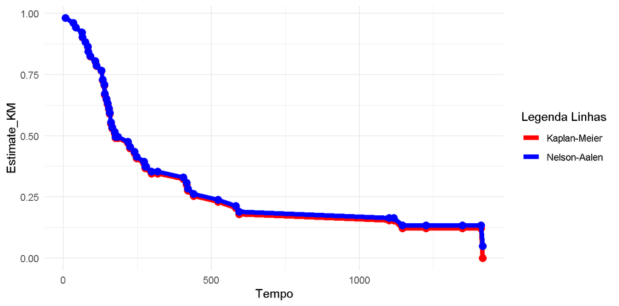

## Letra B

*Os tempos mediano e médio.*

**Para o Estimador Kaplan-Meier:**

Temos que o tempo médio é 414.664 e o tempo mediano é 174.5.

**Para o Estimador Nelson-Aalen:**

Temos que o tempo médio é 426.667 e o tempo mediano é 175.456.

## Letra C

*As probabilidade de um paciente com câncer sobreviver a: i) 42 dias, ii) 100 dias, iii) 300 dias e iv) 1000 dias.*

Nessa questão geraremos estimativas utilizando tanto interpolação quanto as probabilidades geradas pelos **degraus** da curva de sobrevivência dos estimadores.

**Para o Estimador Kaplan-Meier:** Temos que a probabilidade de sobreviver a 42 dias pela curva é 0.941, enquanto pela interpolação é 0.95, para 100, 300 e 1000 dias só conseguimos estimar com a interpolação, que são 0.813, 0.345 e 0.159, respectivamente.

**Para o Estimador Nelson-Aalen:**

Temos que a probabilidade de sobreviver a 42 dias pela curva é 0.942, enquanto pela interpolação é 0.95, para 100, 300 e 1000 dias só conseguimos estimar com a interpolação, que são 0.815, 0.353 e 0.169, respectivamente.

## Letra D

*O tempo médio de vida restante dos pacientes que sobreviveram 1000 dias*

**Para o Estimador Kaplan-Meier:**

Temos que o tempo médio restante é 354.387.

**Para o Estimador Nelson-Aalen:**

Temos que o tempo médio restante é 359.954.

## Letra E

*Interprete as estimativas obtidas nos três itens anteriores*

Como a interpretação para o estimador de Kaplan-Meier é análoga a interpretação para o estimador de Nelson-Aalen, interpretação apenas as estimativas do estimador de Kaplan-Meier por ser o mais utilizado.

Com o tempo médio e mediano podemos fornecer medidas de tendência central para a curva de sobrevivência, assim o tempo médio e tempo mediano fornecem a média e mediana de sobrevivência dos indivíduos neste modelo.

Verificando a probabilidade de sobrevicência para 42, 100, 300 e 1000 dias temos a probabilidade de um paciente com câncer sobreviver pelo menos esse tempo.

O tempo médio de vida restante, verificamos um paciente que sobreviveu até 1000 dias, qual o tempo médio de sobrevivência restante, ou seja, dado que sobreviveu 1000 dias, quanto tempo mais o paciente vai sobreviver.

# Letra F

*Para quais tempos tem-se: S(t) = 0.80, S(t) = 0.30, S(t) = 0.10? Interprete*

**Para o Estimador Kaplan-Meier:**

Dado a estimativa da probabilidade de sobrevivência de 0.8, 0.3 e 0.1, temos que o tempo associado a essas probabilidades é: 108.8, 416.94 e 1196.728, respectivamente.

**Para o Estimador Nelson-Aalen:**

Dado a estimativa da probabilidade de sobrevivência de 0.8, 0.3 e 0.1, temos que o tempo associado a essas probabilidades é: 109.201, 418.039 e 1255.346, respectivamente.

#Questão 4

```
##  [1]   9  13  13  18  23  28  31  34  45  48 161   5   5   8   8  12  16  23  27
## [20]  30  33  43  45
```